# Meta-analysis of synesthetic metaphor tables

Bodo

2023-07-10

# 1 Introduction

This script looks at percent hierarchy consistency. Since this is our first analysis, we’ll also spend some time checking datasets to report overall statistics in the paper.

Load tables:

```r
# List of all tables:

load('../additional_data/all_included_tables_list.RData')
```

# 2 Important note

# 3 Simple check, overall proportion

Add *all* tables on top of each other:

```r
empty_tab <- matrix(c(NA, 0, 0, 0, 0,
                      0, NA, 0, 0, 0,
                      0, 0, NA, 0, 0,
                      0, 0, 0, NA, 0,
                      0, 0, 0, 0, NA),
                    byrow = TRUE, nrow = 5)

# Loop:

for (i in 1:length(both_tables)) {
  empty_tab <- empty_tab + both_tables[[i]]
}

# Show:

empty_tab
```

```
##         touch taste smell hearing sight
## touch      NA   369   754    6377  5034
## taste     447    NA  1240    2114  3100
## smell      40    85    NA      76    89
## hearing    90    31    51      NA   674
## sight    1365   187   310    6096    NA
```

Check the overall proportion of each cell:

```r
round(empty_tab / sum(empty_tab, na.rm = TRUE), 3)
```

```
##         touch taste smell hearing sight
## touch      NA 0.013 0.026   0.224 0.176
## taste   0.016    NA 0.043   0.074 0.109
## smell   0.001 0.003    NA   0.003 0.003
## hearing 0.003 0.001 0.002      NA 0.024
## sight   0.048 0.007 0.011   0.214    NA
```

# 4 Setup

```r
library(tidyverse)     # for data processing and visualization
library(brms)          # for fitting bayesian models
library(tidybayes)     # for spread_draws()
library(patchwork)     # for multi plot arrays
library(png)     # for loading png files
library(grid)# for rasterGrob()
```

Check package version for the new package:

```r
packageVersion('png')
```

```
## [1] '0.1.8'
```

Load the `both_tables` list that has been created in the `table_preprocessing.Rmd` file.

```r
# List of all tables:

load('../additional_data/all_included_tables_list.RData')
```

Show 5 random rows each to get an overview:

```r
# List of all tables:

both_tables[sample(1:length(both_tables), 5)]
```

```
## $whitney_1952_kosztolanyi
##         touch taste smell hearing sight
## touch      NA     1     4      17    10
## taste       3    NA     2       3     5
## smell       0     0    NA       2     1
## hearing     5     0     1      NA    15
## sight       6     0     1      20    NA
##
## $catricalà_2008_spanish
##         touch taste smell hearing sight
## touch      NA     2     1      10     9
## taste       0    NA     2       2     2
## smell       0     0    NA       0     0
## hearing     2     0     0      NA     6
## sight       0     0     0      10    NA
##
## $paissa_italian_1995
##         touch taste smell hearing sight
## touch      NA     8     3      23    20
## taste       2    NA     9       9     3
## smell       0     1    NA       0     0
## hearing     0     1     1      NA     6
## sight       1     0     1      19    NA
##
## $whitney_1952_babits
##         touch taste smell hearing sight
## touch      NA     2     2      34    37
## taste       2    NA     6       7     8
## smell       1     1    NA       5     0
## hearing     7     2     6      NA    27
## sight       0     1     0      37    NA
##
## $whitney_1952_jozsef
##         touch taste smell hearing sight
## touch      NA     1     4      23    41
## taste       1    NA     2       3     0
## smell       0     0    NA       1     1
## hearing     7     1     1      NA    20
## sight       5     0     3      19    NA
```

Load metadata and rename columns as desired:

```r
metadata <- read_csv('../metadata.csv') %>%
  rename(genre = Genre,
         language = `Language of data`,
         source = `Type of data source`,
         table_title = `Table title`)
```

# 5 Demonstrate the approach

In the methods section, we’ll explain the concept of standardized residuals using Winter’s (2019) table:

```r
winter_2019 <- both_tables$winter_2019_tokens

winter_2019
```

```
##         touch taste smell hearing sight
## touch      NA    56   275    1677   560
## taste      66    NA   742     288    40
## smell      10    51    NA       4     6
## hearing     7     5    10      NA   108
## sight     416    75   149    1080    NA
```

Take the first row, cells `2:5`, as we don’t need the `NA` case in here:

```r
winter_2019 <- winter_2019[1, 2:5]

winter_2019
```

```
##   taste   smell hearing   sight
##      56     275    1677     560
```

Show the obseved and expected values for comparison, as well as the unstandardized and standardized residuals:

```r
chisq.test(winter_2019)$observed
```

```
##   taste   smell hearing   sight
##      56     275    1677     560
```

```r
chisq.test(winter_2019)$expected
```

```
##   taste   smell hearing   sight
##     642     642     642     642
```

```r
chisq.test(winter_2019)$residuals
```

```
##      taste      smell    hearing      sight
## -23.127575 -14.484335  40.848192  -3.236282
```

```r
chisq.test(winter_2019)$stdres
```

```
##      taste      smell    hearing      sight
## -26.705424 -16.725069  47.167429  -3.736936
```

# 6 Compute all standardized residuals

This was just a demo for one row — we need to repeat this for a) all five modalities, and b) for each dataset. This is achieved by the next loop:

```r
# Setup empty list for saving:

stdres <- list()

# Loop through and get all standardized residuals:

for (i in seq_along(both_tables)) {
  # Check if there is heat/touch, checking for column suffices here:

  M <- both_tables[[i]]

  # Create empty table to be filled:

  M_stdres <- c()

  # Loop through five rows

  for (j in 1:5) {

    # extract row and compute standardized residuals

    this_row <- M[j, ]

    if (sum(this_row, na.rm = TRUE) != 0) { # if row is not entirely zero

      this_stdres <- chisq.test(this_row[-j])$stdres

      # append NAs to the spot where the diagonal would be, so that we can reappend it to a matrix

      if (j == 1) { this_stdres <- c(NA, this_stdres); names(this_stdres)[1] <- 'touch'}
      if (j == 2) { this_stdres <- c(this_stdres[1], NA, this_stdres[2:4]) }
      if (j == 3) { this_stdres <- c(this_stdres[1:2], NA, this_stdres[3:4]) }
      if (j == 4) { this_stdres <- c(this_stdres[1:3], NA, this_stdres[4]) }
      if (j == 5) { this_stdres <- c(this_stdres, NA) }

    } else {  # if row is entirely zero, set to NA
      this_stdres <- rep(NA, 5)
    }

    # Put into table:

    M_stdres <- rbind(M_stdres, this_stdres)
    }

    # Set diagonal to NA:

    diag(M_stdres) <- NA

    # Add row names:

    row.names(M_stdres) <- c('touch', 'taste', 'smell', 'hearing', 'sight')

    # Chi-Square test and extracting residuals:

    stdres[[i]] <- M_stdres
}
```

Show:

```r
stdres[1:5]
```

```
## [[1]]
##              touch      taste      smell   hearing      sight
## touch           NA -1.1547005 -1.7320508 2.8867513  0.0000000
## taste    0.3333333         NA -1.0000000 1.6666667 -1.0000000
## smell    0.8164966 -0.8164966         NA 0.8164966 -0.8164966
## hearing -0.8164966 -0.8164966 -0.8164966        NA  2.4494897
## sight   -0.1924501 -1.7320508 -1.7320508 3.6565517         NA
##
## [[2]]
##              touch       taste       smell    hearing      sight
## touch           NA -16.2473138 -13.8667550 32.8715495 -2.7574806
## taste   -5.5603844          NA  -1.2510865 11.1207687 -4.3092979
## smell   -0.8164966  -0.8164966          NA  0.8164966  0.8164966
## hearing -2.3094011  -3.4641016  -0.7698004         NA  6.5433031
## sight   -4.3878620  -5.7735027  -2.5403412 12.7017059         NA
##
## [[3]]
##             touch      taste      smell    hearing      sight
## touch          NA -6.7109832 -5.3591305 18.3948533 -6.3247396
## taste   -2.236068         NA  0.1490712  3.1304952 -1.0434984
## smell    1.732051 -0.5773503         NA -0.5773503 -0.5773503
## hearing -1.000000 -1.0000000 -1.0000000         NA  3.0000000
## sight   -1.441153 -2.0816660 -2.0816660  5.6044854         NA
##
## [[4]]
##             touch      taste      smell   hearing      sight
## touch          NA -19.330595 -17.843626 23.662200 13.5120210
## taste   -8.653503         NA -12.654585 20.563701  0.7443874
## smell   -1.745743  -3.055050         NA  1.309307  3.4914862
## hearing -2.811603  -5.573879  -4.784657        NA 13.1701388
## sight   -7.906788 -10.562504 -10.079646 28.548939         NA
##
## [[5]]
##             touch      taste      smell  hearing     sight
## touch          NA -2.3728950 -2.3728950 4.081379 0.6644106
## taste   -2.914610         NA -0.1005038 2.713602 0.3015113
## smell   -1.000000 -1.0000000         NA 1.666667 0.3333333
## hearing -1.527525 -0.6546537 -0.6546537       NA 2.8368326
## sight   -1.549193 -2.0655911 -0.5163978 4.131182        NA
```

We’ll take this to grow a data frame (shame on me) to have everything in a format that we can use ggplot and statistical models with.

```r
# Initialize empty object to be grown:

stdres_df <- c()

# Loop through and get all standardized residuals:

for (i in seq_along(stdres)) {

  # Get table of standardized residuals:

  M <- stdres[[i]]

  # Unpack and make into long format:

  this_df <- M %>%
    as.data.frame() %>%
    rownames_to_column(var = 'source') %>%
    pivot_longer(cols = touch:sight,
                 values_to = 'stdres',
                 names_to = 'target')

  # Append the namne of the table:

  this_df$table_title <- names(both_tables)[i]

  # Append this temporary data frame to the results data frame:

  stdres_df <- rbind(stdres_df, this_df)
}
```

Check:

```r
stdres_df
```

```
## # A tibble: 950 × 4
##    source target  stdres table_title
##    <chr>  <chr>    <dbl> <chr>
##  1 touch  touch   NA     bretones-callejas_2001_heaney
##  2 touch  taste   -1.15  bretones-callejas_2001_heaney
##  3 touch  smell   -1.73  bretones-callejas_2001_heaney
##  4 touch  hearing  2.89  bretones-callejas_2001_heaney
##  5 touch  sight    0     bretones-callejas_2001_heaney
##  6 taste  touch    0.333 bretones-callejas_2001_heaney
##  7 taste  taste   NA     bretones-callejas_2001_heaney
##  8 taste  smell   -1     bretones-callejas_2001_heaney
##  9 taste  hearing  1.67  bretones-callejas_2001_heaney
## 10 taste  sight   -1     bretones-callejas_2001_heaney
## # ℹ 940 more rows
```

# 7 Bayesian models for this

For simplicity, we’ll fit five Bayesian models — otherwise we’ll have to deal with *lots* of interactions and arithmetic to recompute all cells. This way we don’t use information from across rows, thus treating each source as standalone.

But first we’ll need to merge the language metadata back in here so we can have a random effect for language:

```r
stdres_df <- left_join(stdres_df,
                       select(metadata, table_title, language))
```

Priors: the most theoretically important bit here is `prior(normal(0, 5), class = b/Intercept)`, which is a fairly conservative weakly informative prior given the high standardized residuals we can expect to observe (e.g., given Winter 2019’s data) biasing the estimates of each condition difference closer to 0.

```r
my_priors <- c(prior(normal(0, 5), class = Intercept),
               prior(normal(0, 5), class = b),
               prior(student_t(3, 0, 2.5), class = sd), # df = 3, mu = 0, sigma = 2.5
               prior(lkj(2), class = cor))
```

Fit the touch model:

```r
touch_stdres_mdl <- brm(stdres ~

                          # Fixed effects:

                          1 + target +

                          # Random effects:

                          (1 + target|language),

                        data = filter(stdres_df,
                                      source == 'touch',
                                      !is.na(stdres)),
                        family = gaussian,

                        # Priors:

                        prior = my_priors,

                        # MCMC settings:

                        seed = 42, cores = 4, chains = 4,
                        iter = 8000, warmup = 5500,
                        control = list(adapt_delta = 0.99),
                        save_pars = save_pars(all = TRUE))

# Save the model:

save(touch_stdres_mdl, file = '../models/touch_stdres_mdl.RData')
```

Fit the taste model:

```r
taste_stdres_mdl <- brm(stdres ~

                          # Fixed effects:

                          1 + target +

                          # Random effects:

                          (1 + target|language),

                        data = filter(stdres_df,
                                      source == 'taste',
                                      !is.na(stdres)),
                        family = gaussian,

                        # Priors:

                        prior = my_priors,

                        # MCMC settings:

                        seed = 42, cores = 4, chains = 4,
                        iter = 8000, warmup = 5500,
                        control = list(adapt_delta = 0.99),
                        save_pars = save_pars(all = TRUE))

# Save the model:

save(taste_stdres_mdl, file = '../models/taste_stdres_mdl.RData')
```

Fit the smell model:

```r
smell_stdres_mdl <- brm(stdres ~

                          # Fixed effects:

                          1 + target +

                          # Random effects:

                          (1 + target|language),

                        data = filter(stdres_df,
                                      source == 'smell',
                                      !is.na(stdres)),
                        family = gaussian,

                        # Priors:

                        prior = my_priors,

                        # MCMC settings:

                        seed = 42, cores = 4, chains = 4,
                        iter = 8000, warmup = 5500,
                        control = list(adapt_delta = 0.99),
                        save_pars = save_pars(all = TRUE))

# Save the model:

save(smell_stdres_mdl, file = '../models/smell_stdres_mdl.RData')
```

Fit the sight model:

```r
sight_stdres_mdl <- brm(stdres ~

                          # Fixed effects:

                          1 + target +

                          # Random effects:

                          (1 + target|language),

                        data = filter(stdres_df,
                                      source == 'sight',
                                      !is.na(stdres)),
                        family = gaussian,

                        # Priors:

                        prior = my_priors,

                        # MCMC settings:

                        seed = 42, cores = 4, chains = 4,
                        iter = 8000, warmup = 5500,
                        control = list(adapt_delta = 0.99),
                        save_pars = save_pars(all = TRUE))

# Save the model:

save(sight_stdres_mdl, file = '../models/sight_stdres_mdl.RData')
```

Fit the sound model:

```r
sound_stdres_mdl <- brm(stdres ~

                          # Fixed effects:

                          1 + target +

                          # Random effects:

                          (1 + target|language),

                        data = filter(stdres_df,
                                      source == 'hearing',
                                      !is.na(stdres)),
                        family = gaussian,

                        # Priors:

                        prior = my_priors,

                        # MCMC settings:

                        seed = 42, cores = 4, chains = 4,
                        iter = 8000, warmup = 5500,
                        control = list(adapt_delta = 0.99),
                        save_pars = save_pars(all = TRUE))

# Save the model:

save(sound_stdres_mdl, file = '../models/sound_stdres_mdl.RData')
```

Load the models in the script:

```r
load('../models/touch_stdres_mdl.RData')
load('../models/taste_stdres_mdl.RData')
load('../models/smell_stdres_mdl.RData')
load('../models/sight_stdres_mdl.RData')
load('../models/sound_stdres_mdl.RData')
```

# 8 Visualize posterior

Get all posterior samples:

```r
touch_posts <- touch_stdres_mdl |>
  spread_draws(b_Intercept, b_targettaste, b_targetsmell, b_targetsight) |>
  select(-(.chain:.draw))

taste_posts <- taste_stdres_mdl |>
  spread_draws(b_Intercept, b_targettouch, b_targetsmell, b_targetsight) |>
  select(-(.chain:.draw))

smell_posts <- smell_stdres_mdl |>
  spread_draws(b_Intercept, b_targettaste, b_targettouch, b_targetsight) |>
  select(-(.chain:.draw))

sight_posts <- sight_stdres_mdl |>
  spread_draws(b_Intercept, b_targettaste, b_targetsmell, b_targettouch) |>
  select(-(.chain:.draw))

sound_posts <- sound_stdres_mdl |>
  spread_draws(b_Intercept, b_targettaste, b_targetsmell, b_targettouch) |>
  select(-(.chain:.draw))
```

Calculate the predictions for each cell:

```r
# Touch:

touch <- mutate(touch_posts,
                sound = b_Intercept,
                taste = b_Intercept + b_targettaste,
                smell = b_Intercept + b_targetsmell,
                sight = b_Intercept + b_targetsight) |>
  select(-(b_Intercept:b_targetsight))

# Taste:

taste <- mutate(taste_posts,
                sound = b_Intercept,
                touch = b_Intercept + b_targettouch,
                smell = b_Intercept + b_targetsmell,
                sight = b_Intercept + b_targetsight) |>
  select(-(b_Intercept:b_targetsight))

# Smell:

smell <- mutate(smell_posts,
                sound = b_Intercept,
                touch = b_Intercept + b_targettouch,
                taste = b_Intercept + b_targettaste,
                sight = b_Intercept + b_targetsight) |>
  select(-(b_Intercept:b_targetsight))

# Sight:

sight <- mutate(sight_posts,
                sound = b_Intercept,
                touch = b_Intercept + b_targettouch,
                taste = b_Intercept + b_targettaste,
                smell = b_Intercept + b_targetsmell) |>
  select(-(b_Intercept:b_targettouch))

# Sound:

sound <- mutate(sound_posts,
                sight = b_Intercept,
                touch = b_Intercept + b_targettouch,
                taste = b_Intercept + b_targettaste,
                smell = b_Intercept + b_targetsmell) |>
  select(-(b_Intercept:b_targettouch))
```

Get the 95% intervals for each:

```r
touch_fixefs <- touch |>
  pivot_longer(cols = sound:sight,
               values_to = 'posterior',
               names_to = 'target') |>
  group_by(target) |>
  summarize(lower_CI = quantile(posterior, 0.025),
            upper_CI = quantile(posterior, 0.975),
            mean = mean(posterior))

taste_fixefs <- taste |>
  pivot_longer(cols = sound:sight,
               values_to = 'posterior',
               names_to = 'target') |>
  group_by(target) |>
  summarize(lower_CI = quantile(posterior, 0.025),
            upper_CI = quantile(posterior, 0.975),
            mean = mean(posterior))

smell_fixefs <- smell |>
  pivot_longer(cols = sound:sight,
               values_to = 'posterior',
               names_to = 'target') |>
  group_by(target) |>
  summarize(lower_CI = quantile(posterior, 0.025),
            upper_CI = quantile(posterior, 0.975),
            mean = mean(posterior))

sight_fixefs <- sight |>
  pivot_longer(cols = sound:smell,
               values_to = 'posterior',
               names_to = 'target') |>
  group_by(target) |>
  summarize(lower_CI = quantile(posterior, 0.025),
            upper_CI = quantile(posterior, 0.975),
            mean = mean(posterior))

sound_fixefs <- sound |>
  pivot_longer(cols = sight:smell,
               values_to = 'posterior',
               names_to = 'target') |>
  group_by(target) |>
  summarize(lower_CI = quantile(posterior, 0.025),
            upper_CI = quantile(posterior, 0.975),
            mean = mean(posterior))
```

Make plots of the 95% credible intervals for each target modality, touch:

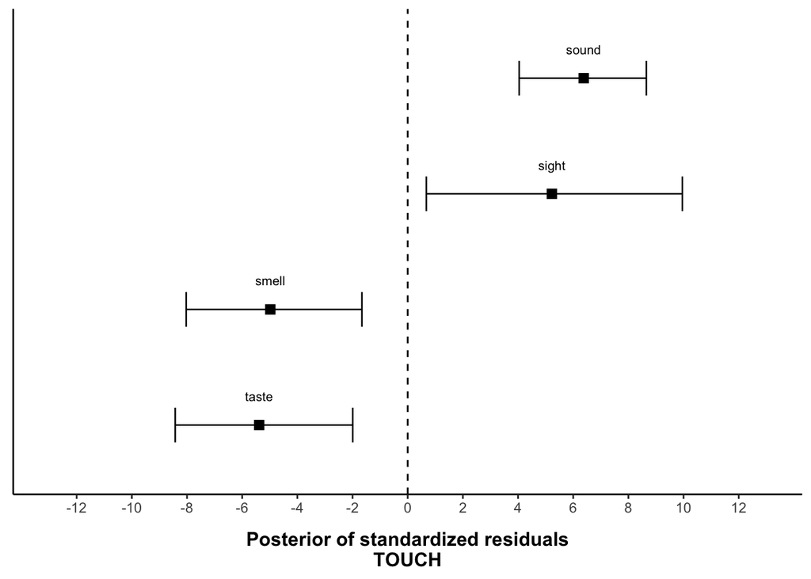

```r
# Plot core:

touch_p <- touch_fixefs |>
  ggplot(aes(x = mean, y = reorder(target, mean))) +
  geom_vline(xintercept = 0, linetype = 'dashed') +
  geom_point(pch = 15, size = 2.7) +
  geom_text(aes(label = target),
            nudge_y = +0.25,
            size = 2.8) +
  geom_errorbar(aes(xmin = lower_CI, xmax = upper_CI),
                width = 0.3, linewidth = 0.45)

# Scales and axes:

touch_p <- touch_p +
  scale_x_continuous(limits = c(-13, 13),
                     breaks = seq(-12, 12, 2)) +
  xlab('Posterior of standardized residuals\nTOUCH') +
  ylab(NULL)

# Cosmetics:

touch_p <- touch_p +
  theme_classic() +
  theme(axis.text.y = element_blank(),
        axis.ticks.y = element_blank(),
        axis.title = element_text(face = 'bold',
                                  size = 12),
        axis.title.x = element_text(margin = margin(t = 10)))

# Show and save:

touch_p
```

```r
ggsave('../figures/pdf/touch_target_preferences.pdf',
       plot = touch_p, width = 4.5, height = 3.2)
ggsave('../figures/png/touch_target_preferences.png',
       plot = touch_p, width = 4.5, height = 3.2)
```

Make plots of the 95% credible intervals for each target modality, taste:

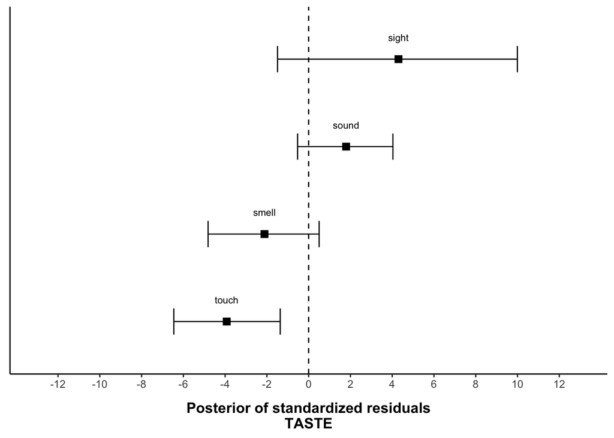

```r
# Plot core:

taste_p <- taste_fixefs |>
  ggplot(aes(x = mean, y = reorder(target, mean))) +
  geom_vline(xintercept = 0, linetype = 'dashed') +
  geom_point(pch = 15, size = 2.7) +
  geom_text(aes(label = target),
            nudge_y = +0.25,
            size = 2.8) +
  geom_errorbar(aes(xmin = lower_CI, xmax = upper_CI),
                width = 0.3, linewidth = 0.45)

# Scales and axes:

taste_p <- taste_p +
  scale_x_continuous(limits = c(-13, 13),
                     breaks = seq(-12, 12, 2)) +
  xlab('Posterior of standardized residuals\nTASTE') +
  ylab(NULL)

# Cosmetics:

taste_p <- taste_p +
  theme_classic() +
  theme(axis.text.y = element_blank(),
        axis.ticks.y = element_blank(),
        axis.title = element_text(face = 'bold',
                                  size = 12),
        axis.title.x = element_text(margin = margin(t = 10)))

# Show and save:

taste_p
```

```r
ggsave('../figures/pdf/taste_target_preferences.pdf',
       plot = taste_p, width = 4.5, height = 3.2)
ggsave('../figures/png/taste_target_preferences.png',
       plot = taste_p, width = 4.5, height = 3.2)
```

Make plots of the 95% credible intervals for each target modality, smell:

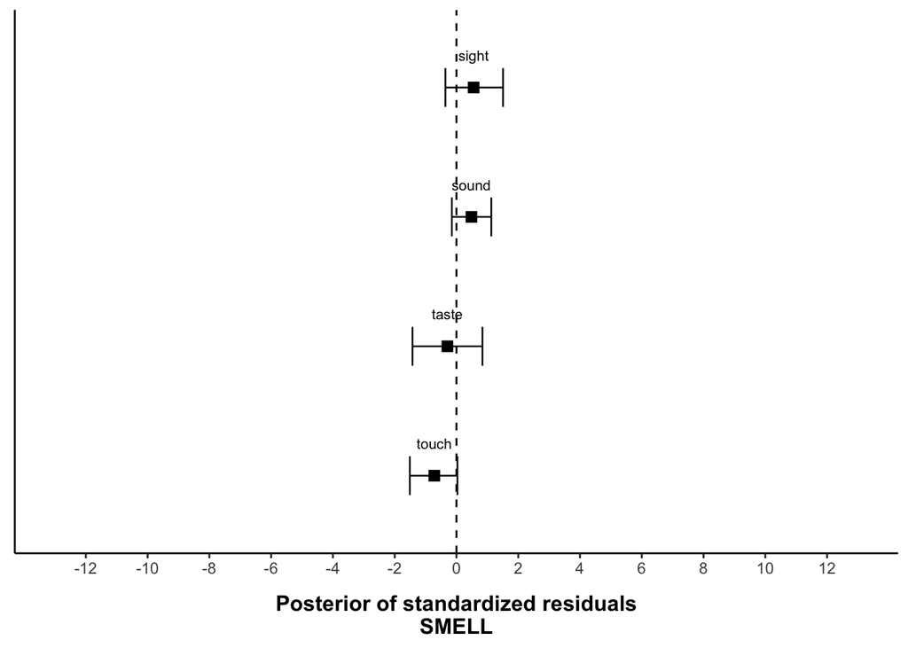

```r
# Plot core:

smell_p <- smell_fixefs |>
  ggplot(aes(x = mean, y = reorder(target, mean))) +
  geom_vline(xintercept = 0, linetype = 'dashed') +
  geom_point(pch = 15, size = 2.7) +
  geom_text(aes(label = target),
            nudge_y = +0.25,
            size = 2.8) +
  geom_errorbar(aes(xmin = lower_CI, xmax = upper_CI),
                width = 0.3, linewidth = 0.45)

# Scales and axes:

smell_p <- smell_p +
  scale_x_continuous(limits = c(-13, 13),
                     breaks = seq(-12, 12, 2)) +
  xlab('Posterior of standardized residuals\nSMELL') +
  ylab(NULL)

# Cosmetics:

smell_p <- smell_p +
  theme_classic() +
  theme(axis.text.y = element_blank(),
        axis.ticks.y = element_blank(),
        axis.title = element_text(face = 'bold',
                                  size = 12),
        axis.title.x = element_text(margin = margin(t = 10)))

# Show and save:

smell_p
```

```r
ggsave('../figures/pdf/smell_target_preferences.pdf',
       plot = smell_p, width = 4.5, height = 3.2)
ggsave('../figures/png/smell_target_preferences.png',
       plot = smell_p, width = 4.5, height = 3.2)
```

Make plots of the 95% credible intervals for each target modality, sight:

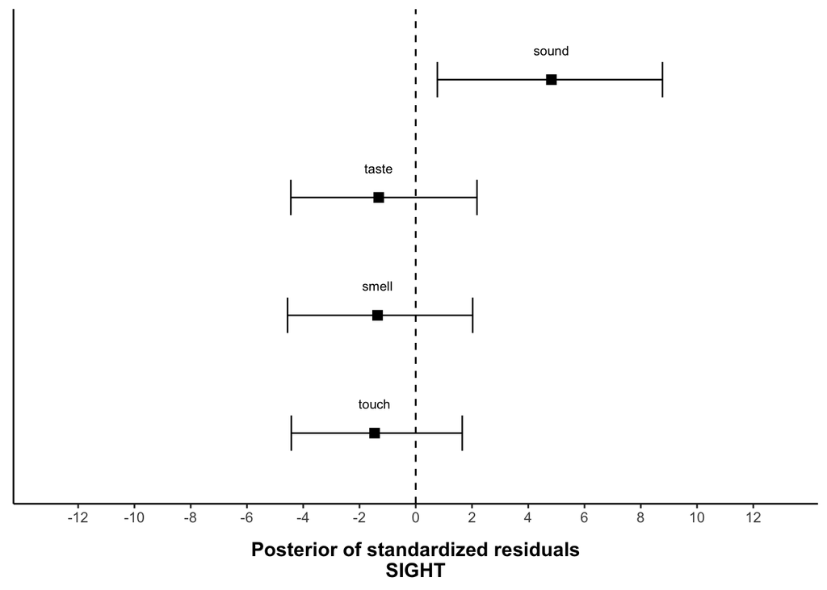

```r
# Plot core:

sight_p <- sight_fixefs |>
  ggplot(aes(x = mean, y = reorder(target, mean))) +
  geom_vline(xintercept = 0, linetype = 'dashed') +
  geom_point(pch = 15, size = 2.7) +
  geom_text(aes(label = target),
            nudge_y = +0.25,
            size = 2.8) +
  geom_errorbar(aes(xmin = lower_CI, xmax = upper_CI),
                width = 0.3, linewidth = 0.45)

# Scales and axes:

sight_p <- sight_p +
  scale_x_continuous(limits = c(-13, 13),
                     breaks = seq(-12, 12, 2)) +
  xlab('Posterior of standardized residuals\nSIGHT') +
  ylab(NULL)

# Cosmetics:

sight_p <- sight_p +
  theme_classic() +
  theme(axis.text.y = element_blank(),
        axis.ticks.y = element_blank(),
        axis.title = element_text(face = 'bold',
                                  size = 12),
        axis.title.x = element_text(margin = margin(t = 10)))

# Show and save:

sight_p
```

```r
ggsave('../figures/pdf/sight_target_preferences.pdf',
       plot = sight_p, width = 4.5, height = 3.2)
ggsave('../figures/png/sight_target_preferences.png',
       plot = sight_p, width = 4.5, height = 3.2)
```

Make plots of the 95% credible intervals for each target modality, sound:

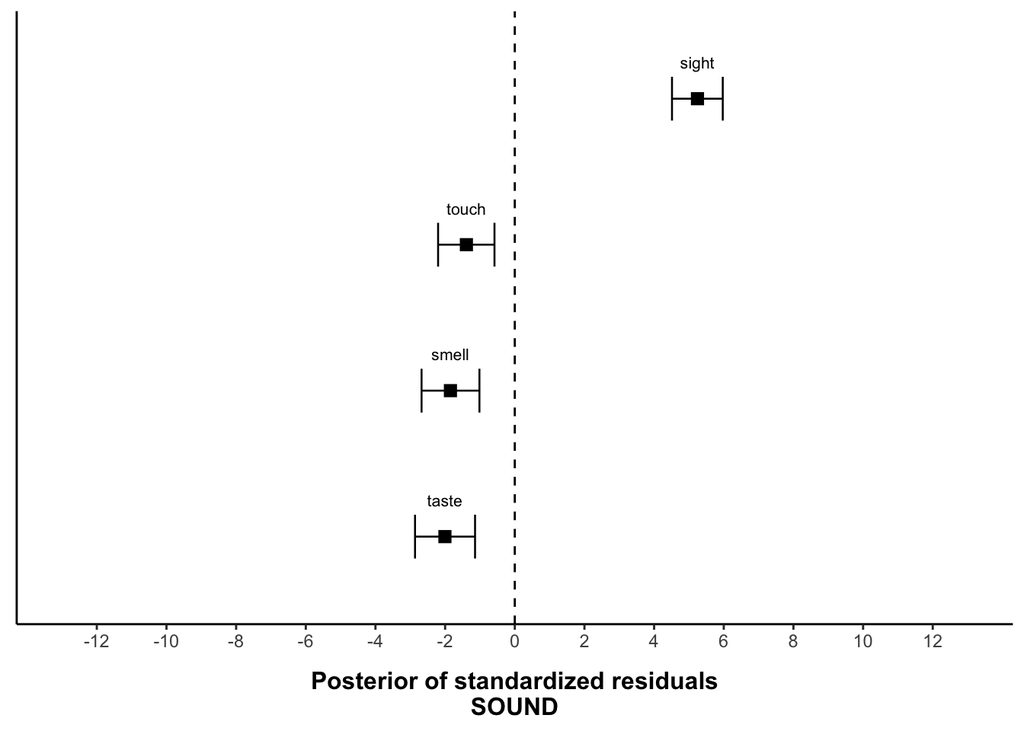

```r
# Plot core:

sound_p <- sound_fixefs |>
  ggplot(aes(x = mean, y = reorder(target, mean))) +
  geom_vline(xintercept = 0, linetype = 'dashed') +
  geom_point(pch = 15, size = 2.7) +
  geom_text(aes(label = target),
            nudge_y = +0.25,
            size = 2.8) +
  geom_errorbar(aes(xmin = lower_CI, xmax = upper_CI),
                width = 0.3, linewidth = 0.45)

# Scales and axes:

sound_p <- sound_p +
  scale_x_continuous(limits = c(-13, 13),
                     breaks = seq(-12, 12, 2)) +
  xlab('Posterior of standardized residuals\nSOUND') +
  ylab(NULL)

# Cosmetics:

sound_p <- sound_p +
  theme_classic() +
  theme(axis.text.y = element_blank(),
        axis.ticks.y = element_blank(),
        axis.title = element_text(face = 'bold',
                                  size = 12),
        axis.title.x = element_text(margin = margin(t = 10)))

# Show and save:

sound_p
```

```r
ggsave('../figures/pdf/sound_target_preferences.pdf',
       plot = sound_p, width = 4.5, height = 3.2)
ggsave('../figures/png/sound_target_preferences.png',
       plot = sound_p, width = 4.5, height = 3.2)
```

Put them all into one plot, lower senses:

```r
# Put all the lower ones together:

lower_p <- touch_p + taste_p + smell_p +
  plot_layout(ncol = 3, nrow = 1)

# Show and save:

ggsave('../figures/pdf/lower_senses_preferences.pdf',
       plot = lower_p, width = 4.5 * 3, height = 3.2)
ggsave('../figures/png/lower_senses_preferences.png',
       plot = lower_p, width = 4.5 * 3, height = 3.2)
```

Put them all into one plot, higher senses:

```r
# Put all the lower ones together:

higher_p <- sight_p + sound_p +
  plot_layout(ncol = 2, nrow = 1)

# Show and save:

ggsave('../figures/pdf/higher_senses_preferences.pdf',
       plot = higher_p, width = 4.5 * 2, height = 3.2)
ggsave('../figures/png/higher_senses_preferences.png',
       plot = higher_p, width = 4.5 * 2, height = 3.2)
```

# 9 Posterior probabilities

Posterior probabilities of preferences for touch:

```r
map_df(touch, .f = function(x) sum(x > 0) / nrow(touch))
```

```
## # A tibble: 1 × 4
##   sound  taste  smell sight
##   <dbl>  <dbl>  <dbl> <dbl>
## 1     1 0.0031 0.0026 0.987
```

Posterior probabilities of preferences for taste:

```r
map_df(taste, .f = function(x) sum(x > 0) / nrow(taste))
```

```
## # A tibble: 1 × 4
##   sound touch  smell sight
##   <dbl> <dbl>  <dbl> <dbl>
## 1 0.937 0.001 0.0538 0.934
```

Posterior probabilities of preferences for smell:

```r
map_df(smell, .f = function(x) sum(x > 0) / nrow(smell))
```

```
## # A tibble: 1 × 4
##   sound  touch taste sight
##   <dbl>  <dbl> <dbl> <dbl>
## 1 0.935 0.0291 0.282 0.893
```

Posterior probabilities of preferences for sound:

```r
map_df(sound, .f = function(x) sum(x > 0) / nrow(sound))
```

```
## # A tibble: 1 × 4
##   sight  touch  taste  smell
##   <dbl>  <dbl>  <dbl>  <dbl>
## 1     1 0.0007 0.0001 0.0003
```

Posterior probabilities of preferences for sight:

```r
map_df(sight, .f = function(x) sum(x > 0) / nrow(sight))
```

```
## # A tibble: 1 × 4
##   sound touch taste smell
##   <dbl> <dbl> <dbl> <dbl>
## 1 0.990 0.153 0.194 0.192
```

# 10 Calculate line strengths

Intuitively, it makes sense that what we believe are strong mappings should include two criteria: first, how strong numerically the mapping is, i.e., a large standardized residual indicates a strong deviation from expected counts; second, how certain we are in a preference. For the latter, we can take the width of the 95% credible interval as an indicator. To bring the two measures in relation so that we can plot line widths that are informed both by frequency counts *and* uncertainty, we can divide the posterior mean (representing the strength) by the width of the interval (representing uncertainty).

Merge them together:

```r
fixefs <- bind_rows(touch_fixefs,
                    taste_fixefs,
                    smell_fixefs,
                    sight_fixefs,
                    sound_fixefs) |>
  mutate(width = abs(upper_CI - lower_CI),
         strength = mean / width)
```

Add source modalities:

```r
fixefs$source <- c(rep('touch', 4),
                   rep('taste', 4),
                   rep('smell', 4),
                   rep('sight', 4),
                   rep('sound', 4))

# Relocate:

fixefs <- fixefs |> relocate(source)
```

Check only the positive ones (the dispreferences just result from over-representation of the preferences):

```r
fixefs <- filter(fixefs, mean > 0)
```

Sort by the strength:

```r
fixefs |>
  arrange(desc(strength)) |>
  mutate(illustrator_strength = strength * 3)
```

```
## # A tibble: 8 × 8
##   source target lower_CI upper_CI  mean width strength illustrator_strength
##   <chr>  <chr>     <dbl>    <dbl> <dbl> <dbl>    <dbl>                <dbl>
## 1 sound  sight     4.51      5.97 5.25   1.46    3.60                10.8
## 2 touch  sound     4.04      8.65 6.38   4.61    1.38                 4.15
## 3 sight  sound     0.768     8.77 4.82   8.00    0.603                1.81
## 4 touch  sight     0.676     9.96 5.23   9.28    0.563                1.69
## 5 taste  sound    -0.531     4.03 1.79   4.57    0.393                1.18
## 6 smell  sound    -0.149     1.13 0.484  1.28    0.379                1.14
## 7 taste  sight    -1.49      9.99 4.30  11.5     0.374                1.12
## 8 smell  sight    -0.358     1.51 0.556  1.87    0.298                0.894
```

What about in terms of just width? (certainty)

```r
fixefs |>
  arrange(width)
```

```
## # A tibble: 8 × 7
##   source target lower_CI upper_CI  mean width strength
##   <chr>  <chr>     <dbl>    <dbl> <dbl> <dbl>    <dbl>
## 1 smell  sound    -0.149     1.13 0.484  1.28    0.379
## 2 sound  sight     4.51      5.97 5.25   1.46    3.60
## 3 smell  sight    -0.358     1.51 0.556  1.87    0.298
## 4 taste  sound    -0.531     4.03 1.79   4.57    0.393
## 5 touch  sound     4.04      8.65 6.38   4.61    1.38
## 6 sight  sound     0.768     8.77 4.82   8.00    0.603
## 7 touch  sight     0.676     9.96 5.23   9.28    0.563
## 8 taste  sight    -1.49      9.99 4.30  11.5     0.374
```

That makes relatively little sense to report as line width. We are very “certain” in the smell->sound mapping being close to zero…

That said, we could map the width of the 95% CrI onto a color gradient:

```r
widths <- fixefs |> pull(width) |> as.vector()

# Define a color gradient going from white to black with fine granularity:

pal_fnc <- colorRampPalette(colors = c('white', 'black'))

# Fine gradient:

col_df <- tibble(id = 1:100, hex = pal_fnc(100),
                 values = seq(15, 0, length.out = 100))

# Show:

col_df
```

```
## # A tibble: 100 × 3
##       id hex     values
##    <int> <chr>    <dbl>
##  1     1 #FFFFFF   15
##  2     2 #FCFCFC   14.8
##  3     3 #F9F9F9   14.7
##  4     4 #F7F7F7   14.5
##  5     5 #F4F4F4   14.4
##  6     6 #F2F2F2   14.2
##  7     7 #EFEFEF   14.1
##  8     8 #ECECEC   13.9
##  9     9 #EAEAEA   13.8
## 10    10 #E7E7E7   13.6
## # ℹ 90 more rows
```

Loop through widths and get the closest color values:

```r
# Setup vector to be filled with hex codes for colors:

hexes <- character(length(widths))

# Loop through and find hex value for minimum distance to value:

for (i in seq_along(widths)) {
  this_width <- widths[i]
  hexes[i] <- col_df[which.min(abs(this_width - col_df$values)), ]$hex
}

# Append:

fixefs$hex <- hexes
```

Show:

```r
fixefs |>
  select(-lower_CI, -upper_CI, -strength) |>
  arrange(desc(mean))
```

```
## # A tibble: 8 × 5
##   source target  mean width hex
##   <chr>  <chr>  <dbl> <dbl> <chr>
## 1 touch  sound  6.38   4.61 #4D4D4D
## 2 sound  sight  5.25   1.46 #191919
## 3 touch  sight  5.23   9.28 #9D9D9D
## 4 sight  sound  4.82   8.00 #888888
## 5 taste  sight  4.30  11.5  #C3C3C3
## 6 taste  sound  1.79   4.57 #4D4D4D
## 7 smell  sight  0.556  1.87 #1E1E1E
## 8 smell  sound  0.484  1.28 #141414
```

Let’s see how it looks like when we map strength onto the color *and* linewidth instead.

```r
strengths <- fixefs |> pull(strength) |> as.vector()

# Define a color gradient going from white to black with fine granularity:

pal_fnc <- colorRampPalette(colors = c('white', 'black'))

# Fine gradient:

col_df <- tibble(id = 1:100, hex = pal_fnc(100),
                 values = seq(0, 3.5, length.out = 100))

# Show:

col_df
```

```
## # A tibble: 100 × 3
##       id hex     values
##    <int> <chr>    <dbl>
##  1     1 #FFFFFF 0
##  2     2 #FCFCFC 0.0354
##  3     3 #F9F9F9 0.0707
##  4     4 #F7F7F7 0.106
##  5     5 #F4F4F4 0.141
##  6     6 #F2F2F2 0.177
##  7     7 #EFEFEF 0.212
##  8     8 #ECECEC 0.247
##  9     9 #EAEAEA 0.283
## 10    10 #E7E7E7 0.318
## # ℹ 90 more rows
```

Loop through widths and get the closest color values:

```r
# Setup vector to be filled with hex codes for colors:

hexes <- character(length(strengths))

# Loop through and find hex value for minimum distance to value:

for (i in seq_along(strengths)) {
  this_strength <- strengths[i]
  hexes[i] <- col_df[which.min(abs(this_strength - col_df$values)), ]$hex
}

# Append:

fixefs$hex_strength <- hexes
```

For strength, let’s multiply it by * 3 to make the lines more visible (this is an innocuous manipulation as it is just a constant).

```r
fixefs |>
  mutate(strength_3 = strength * 3) |>
  arrange(desc(strength_3))
```

```
## # A tibble: 8 × 10
##   source target lower_CI upper_CI  mean width strength hex     hex_strength
##   <chr>  <chr>     <dbl>    <dbl> <dbl> <dbl>    <dbl> <chr>   <chr>
## 1 sound  sight     4.51      5.97 5.25   1.46    3.60  #191919 #000000
## 2 touch  sound     4.04      8.65 6.38   4.61    1.38  #4D4D4D #9A9A9A
## 3 sight  sound     0.768     8.77 4.82   8.00    0.603 #888888 #D3D3D3
## 4 touch  sight     0.676     9.96 5.23   9.28    0.563 #9D9D9D #D5D5D5
## 5 taste  sound    -0.531     4.03 1.79   4.57    0.393 #4D4D4D #E2E2E2
## 6 smell  sound    -0.149     1.13 0.484  1.28    0.379 #141414 #E2E2E2
## 7 taste  sight    -1.49      9.99 4.30  11.5     0.374 #C3C3C3 #E2E2E2
## 8 smell  sight    -0.358     1.51 0.556  1.87    0.298 #1E1E1E #EAEAEA
## # ℹ 1 more variable: strength_3 <dbl>
```

Sort by just the posterior mean:

```r
fixefs |>
  filter(mean > 0) |>
  arrange(desc(mean)) |>
  mutate(mean_2 = mean * 1.5)
```

```
## # A tibble: 8 × 10
##   source target lower_CI upper_CI  mean width strength hex   hex_strength mean_2
##   <chr>  <chr>     <dbl>    <dbl> <dbl> <dbl>    <dbl> <chr> <chr>         <dbl>
## 1 touch  sound     4.04      8.65 6.38   4.61    1.38  #4D4… #9A9A9A       9.57
## 2 sound  sight     4.51      5.97 5.25   1.46    3.60  #191… #000000       7.87
## 3 touch  sight     0.676     9.96 5.23   9.28    0.563 #9D9… #D5D5D5       7.84
## 4 sight  sound     0.768     8.77 4.82   8.00    0.603 #888… #D3D3D3       7.23
## 5 taste  sight    -1.49      9.99 4.30  11.5     0.374 #C3C… #E2E2E2       6.45
## 6 taste  sound    -0.531     4.03 1.79   4.57    0.393 #4D4… #E2E2E2       2.69
## 7 smell  sight    -0.358     1.51 0.556  1.87    0.298 #1E1… #EAEAEA       0.834
## 8 smell  sound    -0.149     1.13 0.484  1.28    0.379 #141… #E2E2E2       0.726
```

# 11 Plot of this with images as network

Load images:

```r
touch <- readPNG('../figures/logos/touch.png', native = TRUE)
taste <- readPNG('../figures/logos/taste.png', native = TRUE)
smell <- readPNG('../figures/logos/smell.png', native = TRUE)
sight <- readPNG('../figures/logos/sight.png', native = TRUE)
sound <- readPNG('../figures/logos/sound.png', native = TRUE)
```

```r
df <- tibble(x = c(1, 2),
             y = c(2, 4))
```

# 12 Asymmetry by cell

First loop through everything and add +1 so that all asymmetries can actually be computed.

```r
# Create copy:

plus_one_tabs <- both_tables

# Loop through and add +1 to copy:

for (i in seq_along(plus_one_tabs)) {
  plus_one_tabs[[i]] <- plus_one_tabs[[i]] + 1
}
```

Create all combinations:

```r
# All modalities:

modalities <- c('touch', 'taste', 'smell', 'hearing', 'sight')

# All combinations:

all_combos <- tibble(source = modalities,
                     target = modalities)

# No same:

all_combos <- tidyr::expand(all_combos, source, target)

# Add empty column:

all_combos$asymmetry <- NA

# Get rid of same cases:

all_combos <- filter(all_combos,
                     source != target)

# Show:

all_combos
```

```
## # A tibble: 20 × 3
##    source  target  asymmetry
##    <chr>   <chr>   <lgl>
##  1 hearing sight   NA
##  2 hearing smell   NA
##  3 hearing taste   NA
##  4 hearing touch   NA
##  5 sight   hearing NA
##  6 sight   smell   NA
##  7 sight   taste   NA
##  8 sight   touch   NA
##  9 smell   hearing NA
## 10 smell   sight   NA
## 11 smell   taste   NA
## 12 smell   touch   NA
## 13 taste   hearing NA
## 14 taste   sight   NA
## 15 taste   smell   NA
## 16 taste   touch   NA
## 17 touch   hearing NA
## 18 touch   sight   NA
## 19 touch   smell   NA
## 20 touch   taste   NA
```

Loop through all tables and compute cell-specific source/target ratios:

```r
# Setup empty object to grow (I'm lazy):

all_res <- c()

# Loop through each table and then through each row of all_combos:

for (i in seq_along(plus_one_tabs)) {
  # Create copy to fill:

  temp_df <- all_combos

  # Extract table:

  this_tab <- plus_one_tabs[[i]]

  # Loop through rows of combinations:

  for (j in 1:nrow(all_combos)) {
    this_source <- temp_df[j, ]$source
    this_target <- temp_df[j, ]$target

    # Source/target ratio for this pair:

    temp_df[j, ]$asymmetry <- this_tab[this_source, this_target] /
      this_tab[this_target, this_source]
  }

  # Append name:

  temp_df$table <- names(plus_one_tabs)[i]

  # Append to main tibble:

  all_res <- bind_rows(all_res, temp_df)
}
```

Check that they are symmetrical:

```r
filter(all_res,
       (source == 'touch' & target == 'taste') | (source == 'taste' & target == 'touch'))
```

```
## # A tibble: 76 × 4
##    source target asymmetry table
##    <chr>  <chr>      <dbl> <chr>
##  1 taste  touch      0.667 bretones-callejas_2001_heaney
##  2 touch  taste      1.5   bretones-callejas_2001_heaney
##  3 taste  touch      3.75  day_1996_english
##  4 touch  taste      0.267 day_1996_english
##  5 taste  touch      0.5   day_1996_german_buddenbrooks
##  6 touch  taste      2     day_1996_german_buddenbrooks
##  7 taste  touch      2.95  doetsch_kraus_1992_1
##  8 touch  taste      0.339 doetsch_kraus_1992_1
##  9 taste  touch      0.5   jo_2017_korean
## 10 touch  taste      2     jo_2017_korean
## # ℹ 66 more rows
```

Check first:

```r
2 / 3
```

```
## [1] 0.6666667
```

```r
3 / 2
```

```
## [1] 1.5
```

Makes sense.

Get rid of half of them since they are duplicated. We’ll do it this way round, from left to right along the table:

- touch <-> taste
- touch <-> smell
- touch <-> sound
- touch <-> sight
- taste <-> smell
- taste <-> sound
- taste <-> sight
- smell <-> sound
- smell <-> sight
- sound <-> sight

```r
all_res <- filter(all_res,
                  !(source == 'taste' & target == 'touch'),
                  !(source == 'smell' & target == 'touch'),
                  !(source == 'hearing' & target == 'touch'),
                  !(source == 'sight' & target == 'touch'),
                  !(source == 'smell' & target == 'taste'),
                  !(source == 'hearing' & target == 'taste'),
                  !(source == 'sight' & target == 'taste'),
                  !(source == 'hearing' & target == 'smell'),
                  !(source == 'sight' & target == 'smell'),
                  !(source == 'sight' & target == 'hearing'))
```

Merge `source` and `target` into a pair variable:

```r
all_res <- mutate(all_res,
                  pair = str_c(source, '_', target))
```

Check it’s the right number of levels:

```r
distinct(all_res, pair)
```

```
## # A tibble: 10 × 1
##    pair
##    <chr>
##  1 hearing_sight
##  2 smell_hearing
##  3 smell_sight
##  4 taste_hearing
##  5 taste_sight
##  6 taste_smell
##  7 touch_hearing
##  8 touch_sight
##  9 touch_smell
## 10 touch_taste
```

Yes, it should be 10 pairs.

Make this into a log asymmetry variable:

```r
all_res <- mutate(all_res,
                  log_asymmetry = log(asymmetry))
```

Reappend language:

```r
all_res <- left_join(all_res,
                     select(metadata, table_title, language),
                     by = c('table' = 'table_title'))

# Show:

all_res
```

```
## # A tibble: 380 × 7
##    source  target  asymmetry table                  pair  log_asymmetry language
##    <chr>   <chr>       <dbl> <chr>                  <chr>         <dbl> <chr>
##  1 hearing sight       0.375 bretones-callejas_200… hear…        -0.981 English
##  2 smell   hearing     2     bretones-callejas_200… smel…         0.693 English
##  3 smell   sight       1     bretones-callejas_200… smel…         0     English
##  4 taste   hearing     3     bretones-callejas_200… tast…         1.10  English
##  5 taste   sight       1     bretones-callejas_200… tast…         0     English
##  6 taste   smell       1     bretones-callejas_200… tast…         0     English
##  7 touch   hearing    10     bretones-callejas_200… touc…         2.30  English
##  8 touch   sight       1.67  bretones-callejas_200… touc…         0.511 English
##  9 touch   smell       1     bretones-callejas_200… touc…         0     English
## 10 touch   taste       1.5   bretones-callejas_200… touc…         0.405 English
## # ℹ 370 more rows
```

# 13 Model pairwise asymmetries

Build a model — take the priors from the source/target ratio model (see `analysis2_source_target_ratios.Rmd`).

```r
my_priors <- c(prior(normal(0, 1), class = Intercept),
               prior(normal(0, 1), class = b),
               prior(student_t(3, 0, 2.5), class = sd), # df = 3, mu = 0, sigma = 2.5
               prior(lkj(2), class = cor))
```

Build the model:

```r
asymmetry_mdl <- brm(log_asymmetry ~

                       # Fixed effects:

                       1 + pair +

                       # Random effects:

                       (1 + pair|language),

                data = all_res,
                family = gaussian,

                # Priors:

                prior = my_priors,

                # MCMC settings:

                seed = 42,
                cores = 4,
                chains = 4,
                iter = 6000,
                warmup = 4000,
                control = list(adapt_delta = 0.99),
                save_pars = save_pars(all = TRUE))

# Save the model:

save(asymmetry_mdl, file = '../models/asymmetry_mdl.RData')
```

Load the pre-compiled model:

```r
load('../models/asymmetry_mdl.RData')
```

Assess whether this is a plausible data-generating process:

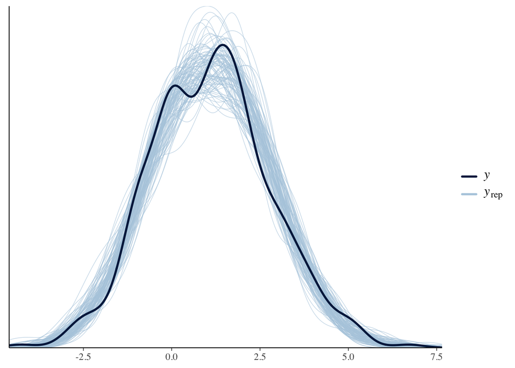

```r
pp_check(asymmetry_mdl, ndraws = 100)
```

Looks quite good!

Check the model:

```r
asymmetry_mdl
```

```
##  Family: gaussian
##   Links: mu = identity; sigma = identity
## Formula: log_asymmetry ~ 1 + pair + (1 + pair | language)
##    Data: all_res (Number of observations: 380)
##   Draws: 4 chains, each with iter = 6000; warmup = 4000; thin = 1;
##          total post-warmup draws = 8000
##
## Group-Level Effects:
## ~language (Number of levels: 14)
##                                          Estimate Est.Error l-95% CI u-95% CI
## sd(Intercept)                                0.18      0.13     0.01     0.50
## sd(pairsmell_hearing)                        0.28      0.23     0.01     0.87
## sd(pairsmell_sight)                          0.43      0.27     0.02     1.05
## sd(pairtaste_hearing)                        1.11      0.38     0.48     1.98
## sd(pairtaste_sight)                          0.97      0.39     0.29     1.82
## sd(pairtaste_smell)                          0.48      0.32     0.02     1.21
## sd(pairtouch_hearing)                        0.97      0.42     0.26     1.96
## sd(pairtouch_sight)                          0.49      0.33     0.02     1.25
## sd(pairtouch_smell)                          0.33      0.25     0.01     0.95
## sd(pairtouch_taste)                          0.85      0.31     0.32     1.56
## cor(Intercept,pairsmell_hearing)            -0.02      0.28    -0.55     0.51
## cor(Intercept,pairsmell_sight)              -0.06      0.28    -0.58     0.50
## cor(pairsmell_hearing,pairsmell_sight)      -0.03      0.27    -0.55     0.50
## cor(Intercept,pairtaste_hearing)             0.06      0.27    -0.49     0.56
## cor(pairsmell_hearing,pairtaste_hearing)     0.05      0.28    -0.49     0.57
## cor(pairsmell_sight,pairtaste_hearing)      -0.07      0.26    -0.57     0.45
## cor(Intercept,pairtaste_sight)               0.08      0.28    -0.47     0.59
## cor(pairsmell_hearing,pairtaste_sight)       0.01      0.27    -0.52     0.53
## cor(pairsmell_sight,pairtaste_sight)         0.01      0.26    -0.49     0.53
## cor(pairtaste_hearing,pairtaste_sight)       0.37      0.23    -0.13     0.76
## cor(Intercept,pairtaste_smell)               0.02      0.27    -0.51     0.53
## cor(pairsmell_hearing,pairtaste_smell)       0.03      0.28    -0.51     0.56
## cor(pairsmell_sight,pairtaste_smell)        -0.06      0.27    -0.57     0.46
## cor(pairtaste_hearing,pairtaste_smell)       0.20      0.27    -0.36     0.67
## cor(pairtaste_sight,pairtaste_smell)         0.18      0.27    -0.38     0.67
## cor(Intercept,pairtouch_hearing)            -0.00      0.27    -0.53     0.52
## cor(pairsmell_hearing,pairtouch_hearing)     0.04      0.27    -0.50     0.54
## cor(pairsmell_sight,pairtouch_hearing)      -0.10      0.26    -0.59     0.42
## cor(pairtaste_hearing,pairtouch_hearing)     0.37      0.24    -0.16     0.77
## cor(pairtaste_sight,pairtouch_hearing)       0.27      0.25    -0.27     0.70
```

[output cut: 87 more lines]

```
## pairtaste_hearing     2.42      0.43     1.51     3.20 1.00     2643     3794
## pairtaste_sight       1.92      0.39     1.03     2.61 1.00     3216     3958
## pairtaste_smell       1.99      0.30     1.35     2.53 1.00     4525     4864
## pairtouch_hearing     3.35      0.42     2.40     4.05 1.00     2529     3649
## pairtouch_sight       2.44      0.31     1.74     2.99 1.00     3999     3937
## pairtouch_smell       2.10      0.27     1.55     2.60 1.00     5437     4927
## pairtouch_taste       0.83      0.35     0.15     1.52 1.00     5644     5795
##
## Family Specific Parameters:
##       Estimate Est.Error l-95% CI u-95% CI Rhat Bulk_ESS Tail_ESS
## sigma     1.05      0.04     0.96     1.14 1.00     5220     5859
##
## Draws were sampled using sampling(NUTS). For each parameter, Bulk_ESS
## and Tail_ESS are effective sample size measures, and Rhat is the potential
## scale reduction factor on split chains (at convergence, Rhat = 1).
```

# 14 Plot 95% intervals

Get the posterior samples from the model:

```r
posts <- asymmetry_mdl |>
  spread_draws(b_Intercept, b_pairsmell_hearing,
               b_pairsmell_sight, b_pairtaste_hearing,
               b_pairtaste_sight, b_pairtaste_smell,
               b_pairtouch_hearing, b_pairtouch_sight,
               b_pairtouch_smell, b_pairtouch_taste)
```

```r
posts <- posts |>
  mutate(smell_sound = b_Intercept + b_pairsmell_hearing,
         smell_sight = b_Intercept + b_pairsmell_sight,
         taste_sound = b_Intercept + b_pairtaste_hearing,
         taste_sight = b_Intercept + b_pairtaste_sight,
         taste_smell = b_Intercept + b_pairtaste_smell,
         touch_sound = b_Intercept + b_pairtouch_hearing,
         touch_sight = b_Intercept + b_pairtouch_sight,
         touch_smell = b_Intercept + b_pairtouch_smell,
         touch_taste = b_Intercept + b_pairtouch_taste) |>
  rename(sound_sight = b_Intercept) |>
  select(-(b_pairsmell_hearing:b_pairtouch_taste),
         -(.chain:.draw))

# Show:

posts
```

```
## # A tibble: 8,000 × 10
##    sound_sight smell_sound smell_sight taste_sound taste_sight taste_smell
##          <dbl>       <dbl>       <dbl>       <dbl>       <dbl>       <dbl>
##  1      -0.628      0.131    -0.523          1.94        1.40         1.54
##  2      -0.602      0.395    -0.236          2.02        1.46         1.69
##  3      -0.560      0.360    -0.122          1.99        1.62         1.61
##  4      -0.782      0.198     0.000417       2.19        0.837        1.18
##  5      -0.806      0.101    -0.387          1.98        1.35         1.32
##  6      -0.726      0.140    -0.136          1.86        1.41         1.50
##  7      -0.858     -0.0243   -0.111          1.44        0.597        1.32
##  8      -0.902     -0.0346   -0.466          1.56        0.416        1.52
##  9      -0.751     -0.283    -0.354          1.34        0.903        1.72
## 10      -0.845     -0.415    -0.298          0.901       1.06         1.43
## # ℹ 7,990 more rows
## # ℹ 4 more variables: touch_sound <dbl>, touch_sight <dbl>, touch_smell <dbl>,
## #   touch_taste <dbl>
```

Compute relevant stats… need to make it long format for that:

```r
posts_long <- posts |>
  pivot_longer(cols = sound_sight:touch_taste,
               names_to = 'pair',
               values_to = 'log_ratio') |>
  arrange(pair)

# Show long format:

posts_long
```

```
## # A tibble: 80,000 × 2
##    pair        log_ratio
##    <chr>           <dbl>
##  1 smell_sight -0.523
##  2 smell_sight -0.236
##  3 smell_sight -0.122
##  4 smell_sight  0.000417
##  5 smell_sight -0.387
##  6 smell_sight -0.136
##  7 smell_sight -0.111
##  8 smell_sight -0.466
##  9 smell_sight -0.354
## 10 smell_sight -0.298
## # ℹ 79,990 more rows
```

Compute 95% credible interval and means:

```r
fixefs <- posts_long |>
  group_by(pair) |>
  summarize(lower_CI = quantile(log_ratio, 0.025),
            upper_CI = quantile(log_ratio, 0.975),
            estimate = mean(log_ratio))

# Show:

fixefs
```

```
## # A tibble: 10 × 4
##    pair        lower_CI upper_CI estimate
##    <chr>          <dbl>    <dbl>    <dbl>
##  1 smell_sight   -0.671    0.258   -0.197
##  2 smell_sound   -0.270    0.592    0.171
##  3 sound_sight   -1.05    -0.377   -0.710
##  4 taste_sight    0.337    1.86     1.21
##  5 taste_smell    0.658    1.75     1.28
##  6 taste_sound    0.807    2.44     1.71
##  7 touch_sight    1.06     2.21     1.73
##  8 touch_smell    0.894    1.82     1.39
##  9 touch_sound    1.68     3.29     2.64
## 10 touch_taste   -0.498    0.730    0.117
```

Split into pairs:

```r
fixefs <- separate(fixefs, pair,
                   into = c('first', 'second'), remove = FALSE)
```

Order them by strength:

```r
fixefs <- arrange(fixefs, desc(estimate))

# Sort pair by order:

fixefs <- fixefs |>
  mutate(pair = factor(pair, levels = rev(fixefs$pair)))
```

Make a plot out of this:

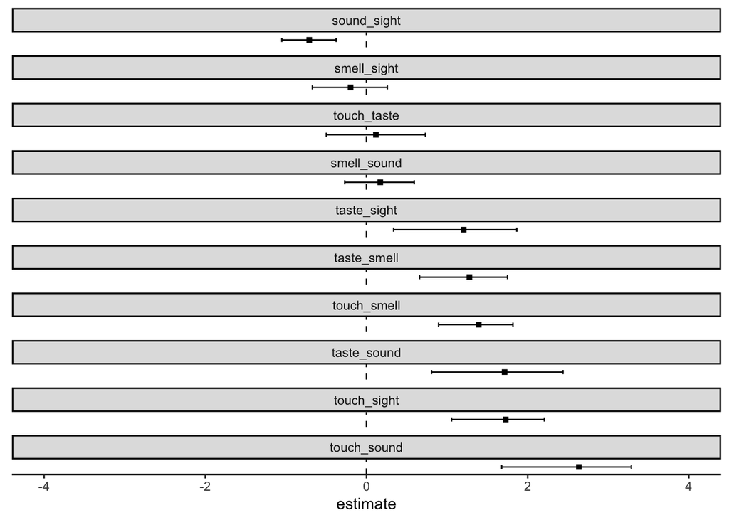

```r
fixefs |>
  ggplot() +
  geom_vline(xintercept = 0, linetype = 'dashed') +
  geom_errorbar(aes(xmin = lower_CI, xmax = upper_CI, y = 0),
                width = 0.3, linewidth = 0.45) +
  geom_point(aes(y = 0, x = estimate),
             pch = 15) +
  ylab(NULL) +
  ylim(-0.5, 0.5) +
  xlim(-4, +4)  +
  facet_wrap(~pair,
             nrow = 10) +
  theme_classic() +
  theme(axis.text.y = element_blank(),
        axis.ticks.y = element_blank(),
        axis.line.y = element_blank(),
        strip.background = element_rect(fill = 'grey88'))
```

```r
ggsave('../figures/png/pairwise_asymmetries.png',
       height = 10, width = 4.5)
```

Build the plot:

[figure not shown]

```r
# Set x-axis columsn for left and right:

xmin_left <- -3.5 - 0.5
xmax_left <- -2.7 - 0.5
xmin_right <- xmin_left * -1 + 0.5
xmax_right <- xmax_left * -1 + 0.5

# Plot core:

pairwise_p <- fixefs |>
  ggplot(aes(y = pair)) +
  geom_vline(xintercept = 0, linetype = 'dashed') +
  geom_errorbar(aes(xmin = lower_CI, xmax = upper_CI),
                width = 0.3, linewidth = 0.75) +
  geom_point(aes(x = estimate),
             pch = 15, size = 2)

# Axes and labels:

pairwise_p <- pairwise_p +
  xlab('Asymmetry') +
  ylab(NULL) +
  scale_x_continuous(limits = c(-4.2, +4.2),
                     breaks = -4:4)

# Cosmetics:

pairwise_p <- pairwise_p +
  theme_classic() +
  theme(axis.text.y = element_blank(),
        axis.ticks.y = element_blank(),
        axis.line.y = element_blank(),
        strip.background = element_rect(fill = 'grey88'),
        axis.title.x = element_text(face = 'bold',
                                    margin = margin(t = 10)))

# Add image annotations, first, left column:

pairwise_p <- pairwise_p +
  annotation_custom(rasterGrob(touch, width = 1, height = 1),
                    xmin = xmin_left, xmax = xmax_left,
                    ymin = 9.75, ymax = 10.25) +
  annotation_custom(rasterGrob(touch, width = 1, height = 1),
                    xmin = xmin_left, xmax = xmax_left,
                    ymin = 8.75, ymax = 9.25) +
  annotation_custom(rasterGrob(taste, width = 1, height = 1),
                    xmin = xmin_left, xmax = xmax_left,
                    ymin = 7.75, ymax = 8.25) +
  annotation_custom(rasterGrob(touch, width = 1, height = 1),
                    xmin = xmin_left, xmax = xmax_left,
                    ymin = 6.75, ymax = 7.25) +
  annotation_custom(rasterGrob(taste, width = 1, height = 1),
                    xmin = xmin_left, xmax = xmax_left,
                    ymin = 5.75, ymax = 6.25) +
  annotation_custom(rasterGrob(taste, width = 1, height = 1),
                    xmin = xmin_left, xmax = xmax_left,
                    ymin = 4.75, ymax = 5.25) +
  annotation_custom(rasterGrob(touch, width = 1, height = 1),
                    xmin = xmin_left, xmax = xmax_left,
                    ymin = 3.75, ymax = 4.25) +
  annotation_custom(rasterGrob(smell, width = 1, height = 1),
                    xmin = xmin_left, xmax = xmax_left,
                    ymin = 2.75, ymax = 3.25) +
  annotation_custom(rasterGrob(smell, width = 1, height = 1),
                    xmin = xmin_left, xmax = xmax_left,
                    ymin = 1.75, ymax = 2.25) +
  annotation_custom(rasterGrob(sound, width = 1, height = 1),
                    xmin = xmin_left, xmax = xmax_left,
                    ymin = 0.75, ymax = 1.25)

# Add image annotations, second, right column:

pairwise_p <- pairwise_p +
  annotation_custom(rasterGrob(sound, width = 1, height = 1),
                    xmin = xmin_right, xmax = xmax_right,
                    ymin = 9.75, ymax = 10.25) +
  annotation_custom(rasterGrob(sight, width = 1, height = 1),
                    xmin = xmin_right, xmax = xmax_right,
                    ymin = 8.75, ymax = 9.25) +
  annotation_custom(rasterGrob(sound, width = 1, height = 1),
                    xmin = xmin_right, xmax = xmax_right,
                    ymin = 7.75, ymax = 8.25) +
  annotation_custom(rasterGrob(smell, width = 1, height = 1),
                    xmin = xmin_right, xmax = xmax_right,
                    ymin = 6.75, ymax = 7.25) +
  annotation_custom(rasterGrob(smell, width = 1, height = 1),
                    xmin = xmin_right, xmax = xmax_right,
                    ymin = 5.75, ymax = 6.25) +
  annotation_custom(rasterGrob(sight, width = 1, height = 1),
                    xmin = xmin_right, xmax = xmax_right,
                    ymin = 4.75, ymax = 5.25) +
  annotation_custom(rasterGrob(taste, width = 1, height = 1),
                    xmin = xmin_right, xmax = xmax_right,
                    ymin = 3.75, ymax = 4.25) +
  annotation_custom(rasterGrob(sound, width = 1, height = 1),
                    xmin = xmin_right, xmax = xmax_right,
                    ymin = 2.75, ymax = 3.25) +
  annotation_custom(rasterGrob(sight, width = 1, height = 1),
                    xmin = xmin_right, xmax = xmax_right,
                    ymin = 1.75, ymax = 2.25) +
  annotation_custom(rasterGrob(sight, width = 1, height = 1),
                    xmin = xmin_right, xmax = xmax_right,
                    ymin = 0.75, ymax = 1.25)

# Show and save:

pairwise_p
```

```r
ggsave('../figures/png/pairwise_asymmetries.png',
       height = 10, width = 5.5)
ggsave('../figures/pdf/pairwise_asymmetries.pdf',
       height = 10, width = 5.5)
```

This completes this script.